# Rideshare & Bus Ride Exploratory Analysis

Team 16

2023-07-09

## Rideshare

### Data Exploratory

This part aims to look for specific pattern from the [Austin rideshare dataset](https://data.world/andytryba/rideaustin) to identify possible features to be used for regression model analysis.

**Instruction**: Download the “RideAustin_Weather” csv file from the link location and save that under “Data” folder. The code file is to be downloaded into “Code” folder.

Set Working Directory to the current directory under “Code” folder path

#### Call needed libarady and read data into a dataframe

```r
library(dplyr)
library(ggplot2)
library(plotly)
library(gridExtra)
library(tidyverse)
library(lubridate)
```

```r
rideshare <- read.csv('../Data/RideAustin_Weather.csv')

summary(rideshare)
```

```
##  completed_on       distance_travelled end_location_lat end_location_long
##  Length:911057      Min.   :       0   Min.   : 0.00    Min.   :-121.04
##  Class :character   1st Qu.:    3169   1st Qu.:30.25    1st Qu.: -97.75
##  Mode  :character   Median :    5812   Median :30.27    Median : -97.74
##                     Mean   :    8791   Mean   :30.28    Mean   : -97.74
##                     3rd Qu.:   11745   3rd Qu.:30.29    3rd Qu.: -97.73
##                     Max.   :43025760   Max.   :50.02    Max.   :  19.90
##                     NA's   :2
##   started_on        driver_rating     rider_rating   start_zip_code
##  Length:911057      Min.   :0.00     Min.   :0.000   Length:911057
##  Class :character   1st Qu.:5.00     1st Qu.:5.000   Class :character
##  Mode  :character   Median :5.00     Median :5.000   Mode  :character
##                     Mean   :4.82     Mean   :4.906
##                     3rd Qu.:5.00     3rd Qu.:5.000
##                     Max.   :5.00     Max.   :5.000
##                     NA's   :106163   NA's   :22077
##  end_zip_code         charity_id     requested_car_category free_credit_used
##  Length:911057      Min.   : 1.0     Length:911057          Min.   :  0.0
##  Class :character   1st Qu.: 5.0     Class :character       1st Qu.:  6.0
##  Mode  :character   Median :11.0     Mode  :character       Median :  9.3
##                     Mean   :15.2                            Mean   : 10.3
##                     3rd Qu.:25.0                            3rd Qu.: 13.8
##                     Max.   :50.0                            Max.   :103.5
##                     NA's   :700229                          NA's   :724357
##   surge_factor   start_location_long start_location_lat    color
##  Min.   :0.000   Min.   :-121.07     Min.   :29.63      Length:911057
##  1st Qu.:1.000   1st Qu.: -97.75     1st Qu.:30.25      Class :character
##  Median :1.000   Median : -97.74     Median :30.27      Mode  :character
##  Mean   :1.052   Mean   : -97.74     Mean   :30.28
##  3rd Qu.:1.000   3rd Qu.: -97.73     3rd Qu.:30.29
##  Max.   :6.000   Max.   :  19.91     Max.   :50.03
##
##      make              model                year          rating
##  Length:911057      Length:911057      Min.   :2001   Min.   :3.111
##  Class :character   Class :character   1st Qu.:2010   1st Qu.:4.978
##  Mode  :character   Mode  :character   Median :2013   Median :5.000
##                                        Mean   :2012   Mean   :4.975
##                                        3rd Qu.:2015   3rd Qu.:5.000
##                                        Max.   :2104   Max.   :5.000
##
```

[output cut: 9 more lines]

```
##  Min.   : 0.900   Min.   : 6.90   Min.   :0.0000   Min.   :0.00000
##  1st Qu.: 2.500   1st Qu.: 8.90   1st Qu.:0.0000   1st Qu.:0.00000
##  Median : 3.800   Median :12.10   Median :0.0000   Median :0.00000
##  Mean   : 4.141   Mean   :12.11   Mean   :0.4193   Mean   :0.06807
##  3rd Qu.: 5.400   3rd Qu.:14.10   3rd Qu.:1.0000   3rd Qu.:0.00000
##  Max.   :12.300   Max.   :25.90   Max.   :1.0000   Max.   :1.00000
##
##     Thunder
##  Min.   :0.00000
##  1st Qu.:0.00000
##  Median :0.00000
##  Mean   :0.08372
##  3rd Qu.:0.00000
##  Max.   :1.00000
##
```

### Data Wrangling & Transformation

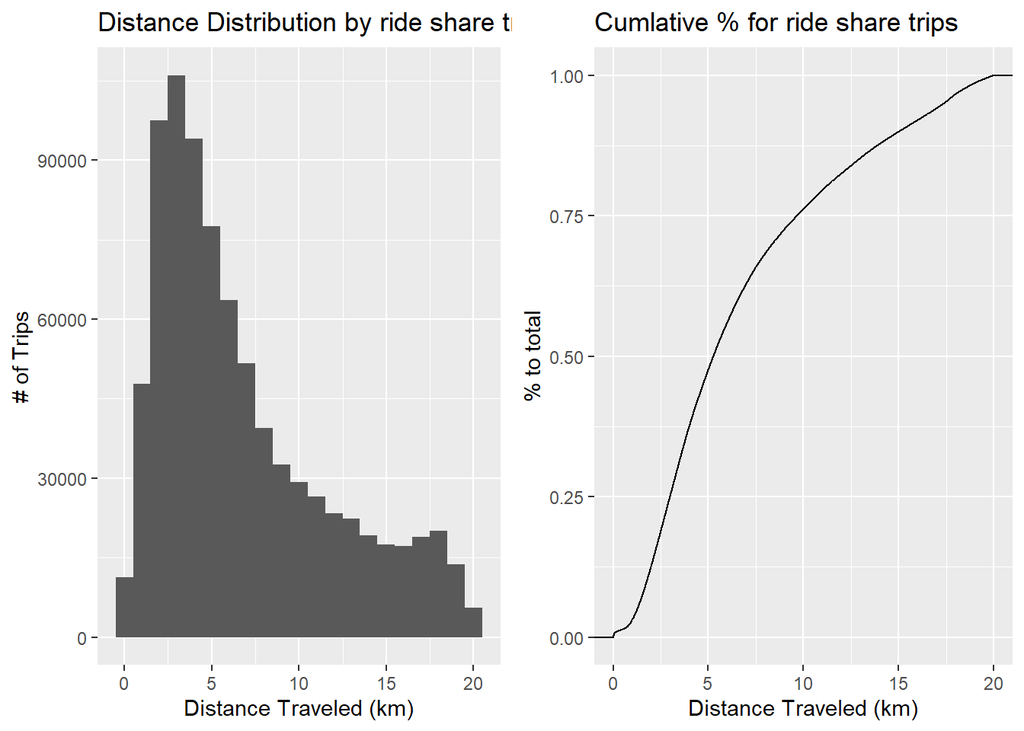

75% of the trips are within 10km. Most bus services probably has route that covers such distance. The question then become why wouldn’t a passenger choose to take public transportation.

Few factors are being considered as follow:

- Time of the day
- Travel duration (assume passengers tolerance of traveled time is < 2 hours)
- Day of the week
- Weather conditions (if impact Day distribution)

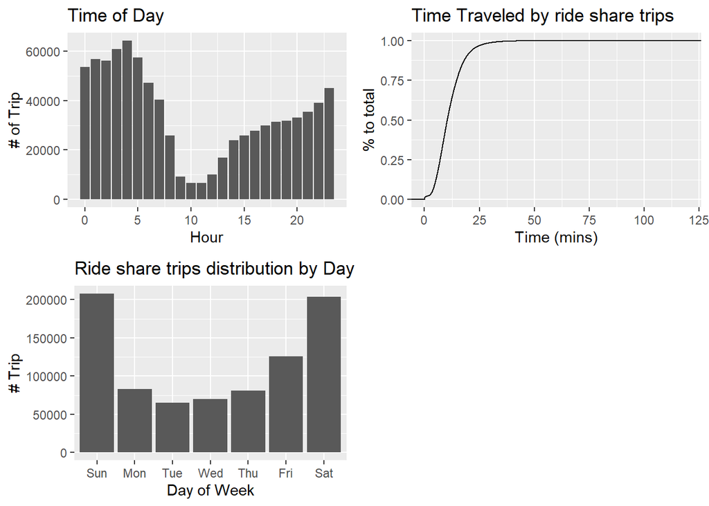

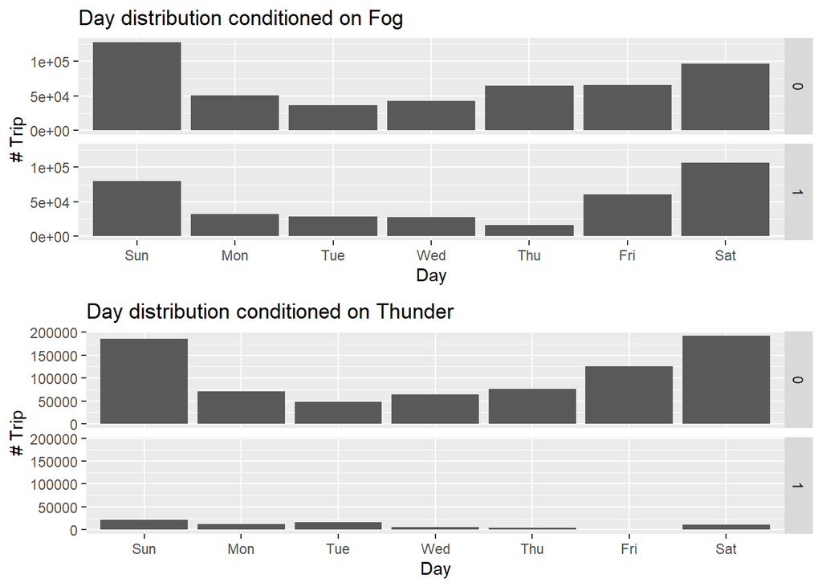

## Bus Ride

Similiar explorations is done on the CapMetro ridership volume [dataset](https://data.texas.gov/Transportation/CapMetro-Shapefiles-AUGUST-2017/5d4c-snum) .

**Instruction**: After downloading the shape file (ths analysis uses August 2017 data) save that under “Data” folder.

#### Read Data into dataframe

```r
capmetro_dow_hour <- read.csv("../Data/CapMetro ridership all by latlong dow hour.csv")
```

#### Perform similiar Visualization as shareride

- Group bus ride volume group by day of week and hour of day
- Sum riders volume based on get_on bus metric to obtain total passengers
- Estimate bus freqency by assuming one row is one bus count

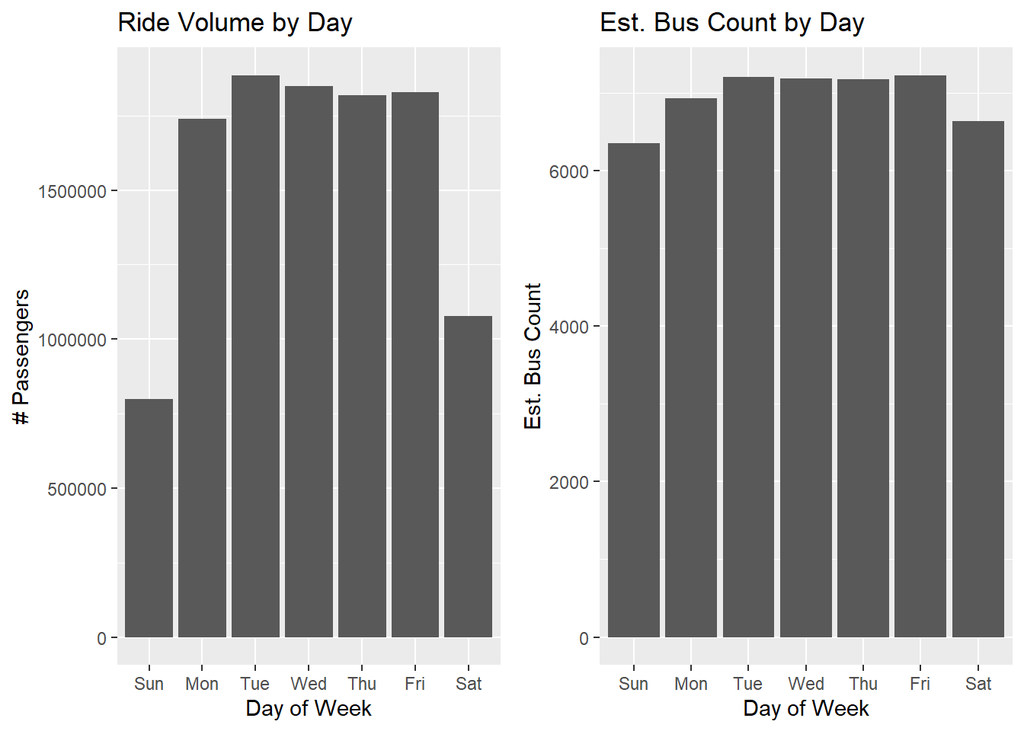

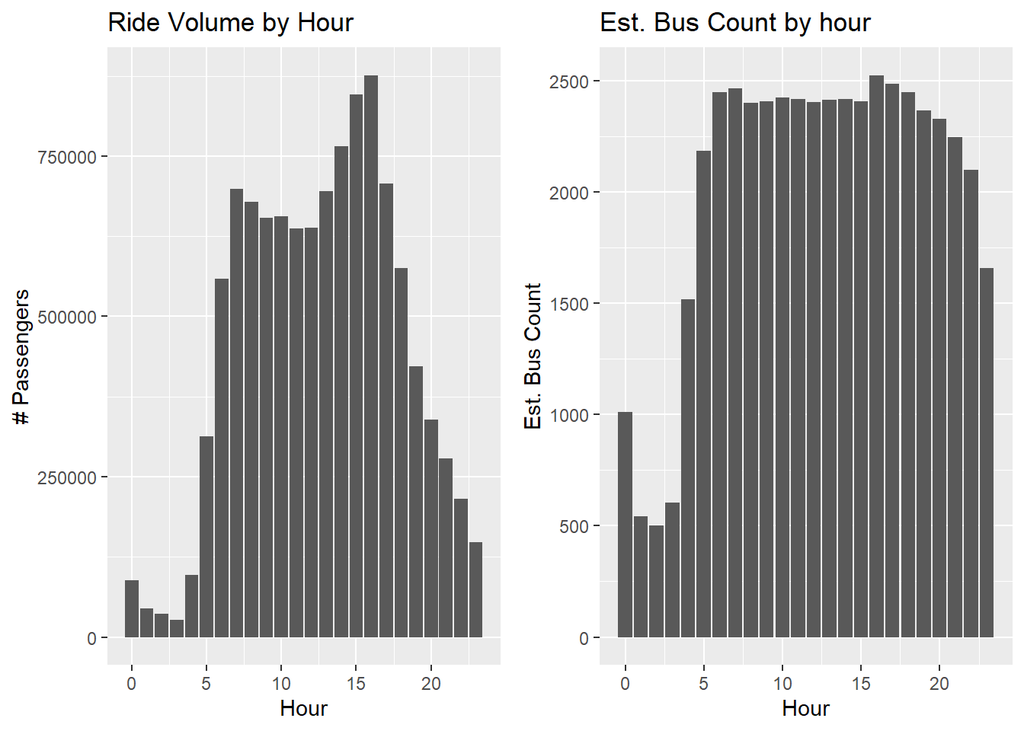

### Observations

- Bus rides occur more often during weekdays vs weekend, even though the estimated number of bus count are not significant different among day of week
- Bus ride occur mostly from 7am to 4pm. Ridership drop drastically till mid-night even though bus frequency stay relative the same throughout the day
- Minimal bus rides from mid-night to 5am, probably driven by reduce in bus frequency

### Anticipated Hypothesis

- Control on day of week, hour of day, and weather condition, higher bus ride volume lead to lower ride share volume
- For the same from and to location, the longer the difference in time among ride share and public transposition, the higher the ride share volume